# 03_Class_Activity

Author

Bill Perry

# In class activity 4:

## What did we do last time in activity 3?

- Setting up a project and variable names and code names
- How to use the pipe command %>%
- How to create descriptive statistics of a sample

```r
p_df %>%
  summarize(
    mean_length = mean(length_mm, na.rm = TRUE),
    sd_length = sd(length_mm, na.rm = TRUE),
    n_length = sum(!is.na(length_mm)))
```

- More graphs…

[figure not shown]

  ```r
  ggplot(data = p_df, aes(x=length_mm, fill = wind)) +
    geom_histogram( binwidth = 2,
  # sets the width in units of the bins - try different nubmers
     position = position_dodge2(width = 0.5))
  ```

- What questions do you have and what is unclear - what did not work so far when you started the homework?

# Introduction

In this active learning module, we’ll explore real data from fish populations in Alaska. We’ll focus on understanding:

- How to create and interpret frequency distributions
- How sample size affects our view of a population
- How distributions differ among lakes

We’ll use the `tidyverse` package for data manipulation and visualization.

## Setup

First, let’s load the packages we need and the dataset:

```r
# # Install the patchwork package if needed

# install.packages("patchwork")
library(patchwork)

library(tidyverse)


# Read in the data file
sculpin_df <- read_csv("data/sculpin.csv")

# Look at the first few rows
head(sculpin_df)
```

```
# A tibble: 6 × 5
   site lake  species       length_mm mass_g
  <dbl> <chr> <chr>             <dbl>  <dbl>
1   146 E 01  slimy sculpin        53   1.25
2   146 E 01  slimy sculpin        61   1.9
3   146 E 01  slimy sculpin        53   1.75
4   146 E 01  slimy sculpin        77   4.25
5   146 E 01  slimy sculpin        45   0.9
6   146 E 01  slimy sculpin        48   0.9
```

## Basic Data Summary

Let’s first check what lakes are in our dataframe:

```r
# Get a list of unique lakes
unique(sculpin_df$lake)
```

```
[1] "E 01"   "E 05"   "NE 12"  "NE 14"  "S 06"   "S 07"   "Toolik"
```

How many fish do we have from each lake?

```r
# Count observations by lake
sculpin_df %>%
  group_by(lake) %>%
  summarize(sculpin_n = n())
```

```
# A tibble: 7 × 2
  lake   sculpin_n
  <chr>      <int>
1 E 01         268
2 E 05          75
3 NE 12        180
4 NE 14         37
5 S 06         132
6 S 07          73
7 Toolik       287
```

```r
# Count observations by lake
sculpin_df %>%
  group_by(lake) %>%
  summarize(sculpin_n = sum(!is.na(length_mm)))
```

```
# A tibble: 7 × 2
  lake   sculpin_n
  <chr>      <int>
1 E 01          79
2 E 05          14
3 NE 12        180
4 NE 14         37
5 S 06         132
6 S 07          73
7 Toolik       208
```

# Part 1: Creating Frequency Distributions

## Basic Histograms

A histogram shows how many observations fall into certain ranges (or “bins”).

Let’s create a simple histogram of fish lengths from Lake E 01 :

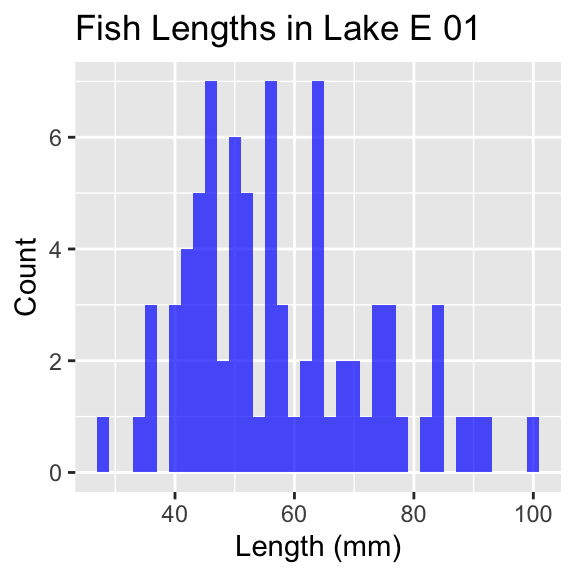

```r
# Filter for Toolik Lake and create a histogram
sculpin_df %>%
  filter(lake == "E 01") %>%
  ggplot(aes(x = length_mm)) +
  geom_histogram(binwidth = 2, fill = "blue", alpha = 0.7) +
  labs(title = "Fish Lengths in Lake E 01",
       x = "Length (mm)",
       y = "Count")
```

**Activity 1**

Try changing the `binwidth` parameter to 5 and then to 1. How does the appearance of the histogram change?

```r
# Try it here
```